# Assignment_1

Jesus A. Gonzalez

Monday, April 13, 2015

# Introduction

The activity data was measured with a personal activity monitoring device. This device obtains data every 5 minutes during the day. The dataset consists of two months of data for the months of October and November of 2012 and measures the number of steps taken by the individual at intervals of 5 minutes for each day.

## Data

The [personal activity dataset](https://d396qusza40orc.cloudfront.net/repdata%2Fdata%2Factivity.zip) (52K) can be found at the following link: https://d396qusza40orc.cloudfront.net/repdata%2Fdata%2Factivity.zip

Data consists of 3 variables:

- **steps**: the number of steps taken in a 5-minute interval
- **date**: the date in which the measurement was taken in the YYYY-MM-DD format
- **interval**: the 5-minute interval id for the measurement

This dataset is formated in a comma-separated-value (CSV) file. It contains a total of 17,568 observations

## Loading the Data

Data is loaded with the “read.csv” command. Then, rows with NA’s are removed as part of the pre-processing step.

```r
    library("dplyr")
    activity_data_orig <- read.csv('repdata-data-activity/activity.csv')
    activity_data <- activity_data_orig[complete.cases(activity_data_orig),]
```

## What is mean total number of steps taken per day?

First we compute the total number of steps taken per day is with the following code and stored in variable **total_by_day**:

```r
    by_day <- group_by(activity_data, date)
    total_by_day <- summarise(by_day, steps = sum(steps))
```

The histogram for the total steps per day is:

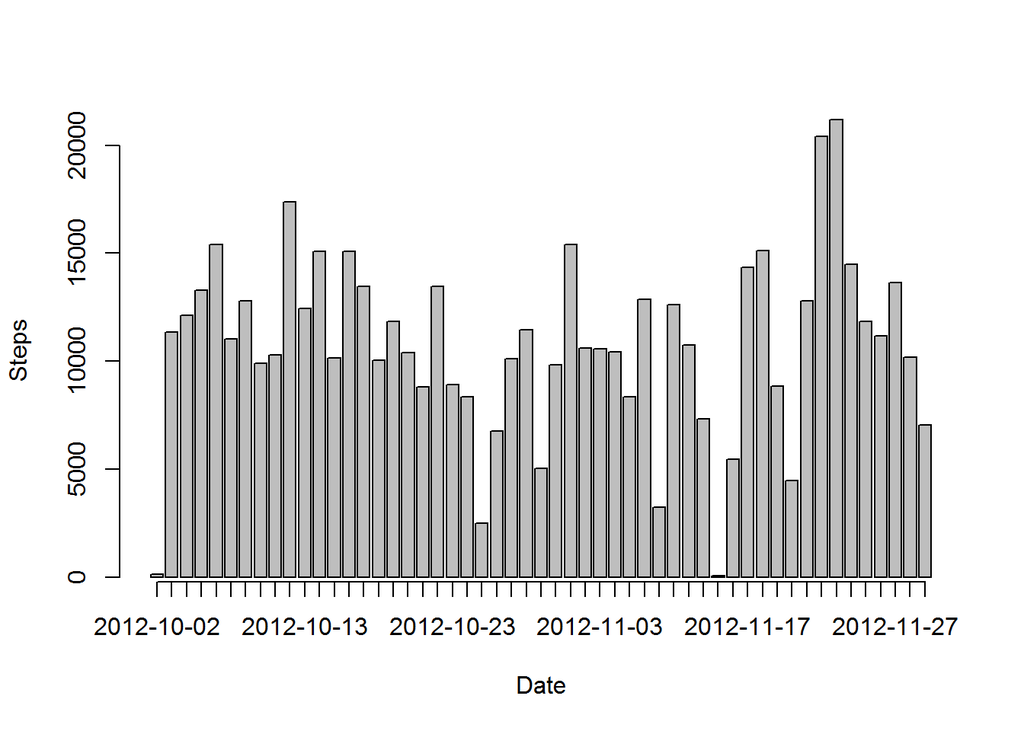

```r
    jpeg(file="figure/plot1.jpg")
    m <- barplot(total_by_day$steps, xlab="Date", ylab="Steps")
    axis(1, at=m, labels=total_by_day$date)
    dev.off()
    m <- barplot(total_by_day$steps, xlab="Date", ylab="Steps")
    axis(1, at=m, labels=total_by_day$date)
```

```r
    mymean <- mean(total_by_day$steps)
    mymedian <- median(total_by_day$steps)
```

The mean and median of the total number of steps taken per day are **10766.1887** and **10765.0000** respectively.

## What is the average daily activity pattern?

We created a time series plot of the 5-minute interval and the average number of steps taken, averaged across all days.

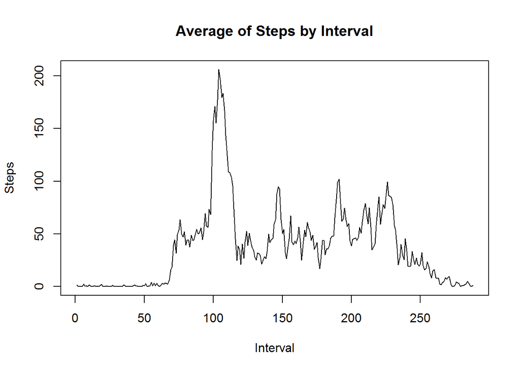

```r
    activity_data$newinterval <- rep(seq(1:288),53)
    by_interval <- group_by(activity_data, newinterval)
    total_by_interval <- summarise(by_interval, steps = mean(steps))
    jpeg(file="figure/plot2.jpg")
    plot(total_by_interval, type="l", xlab="Interval", ylab="Steps", main="Average of Steps by Interval")
    dev.off()

    plot(total_by_interval, type="l", xlab="Interval", ylab="Steps", main="Average of Steps by Interval")
```

### Which 5-minute interval, on average across all the days in the dataset, contains the maximum number of steps?

The 5-minute interval, on average across all the days in the dataset, that contains the maximum number of steps is interval number **104** with an average of steps of **206**.

## Imputing missing values

The total number of missing values in the dataset is: **2304**.

**The strategy used to fill missing values for the “steps” variable is to use the mean value for all days**.

A new dataset that is equal to the original dataset but with the missing data filled in using the abovementioned strategy was created with the following code. The new dataset was stored in variable **activity_data_orig** as follows:

```r
    by_day_orig <- group_by(activity_data_orig, date)
    average_steps_by_day_orig <- summarise(by_day_orig, steps = mean(steps,na.rm=TRUE))
    new_value <- mean(average_steps_by_day_orig$steps, na.rm=TRUE)
    activity_data_orig$steps[is.na(activity_data_orig$steps)] <-
      new_value
```

The new histogram for the total steps per day when replacing missing values by the mean of the values for all days is:

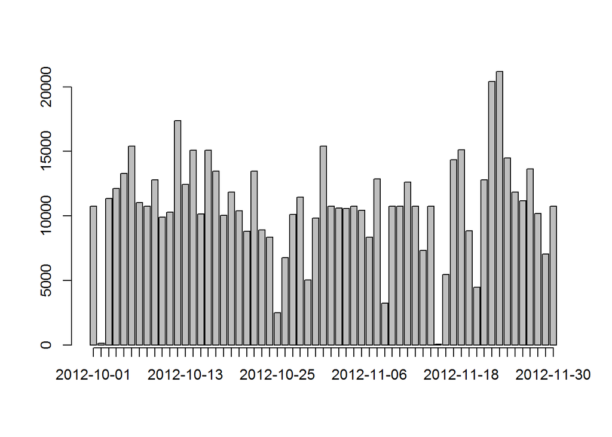

```r
    by_day2 <- group_by(activity_data_orig, date)
    total_by_day2 <- summarise(by_day2, steps = sum(steps))
    jpeg(file="figure/plot3.jpg")
    m <- barplot(total_by_day2$steps)
    axis(1, at=m, labels=total_by_day2$date)
    dev.off()
    m <- barplot(total_by_day2$steps)
    axis(1, at=m, labels=total_by_day2$date)
```

```r
    mymean <- mean(total_by_day2$steps)
    mymedian <- median(total_by_day2$steps)
```

The mean and median of the total number of steps taken per day when replacing missing values by the mean of steps for all days are **10766.1887** and **10766.1887** respectively.

In this case, replacing missing values for the steps attribute with the mean of steps for all days **changed the value of the median steps per day**.

I think that the impact of introducing missing values to the estimates of the total number of daily steps **could bias our results**. In my case, for the first part of this assignment, I removed rows with missing values and I did not see a high impact because the mean value of the total number of steps taken per day **did not change*. On the other hand, the median value changed slightly from the value of the mean. Of course this result is biased because of the way in which I replaced missing values.

## Are there differences in activity patterns between weekdays and weekends?

In order to verify whether there are differences in activity patterns between weekdays and weekends we present a plot for the average interval steps for weekdays and other for weekends. We then are able to compare the patterns:

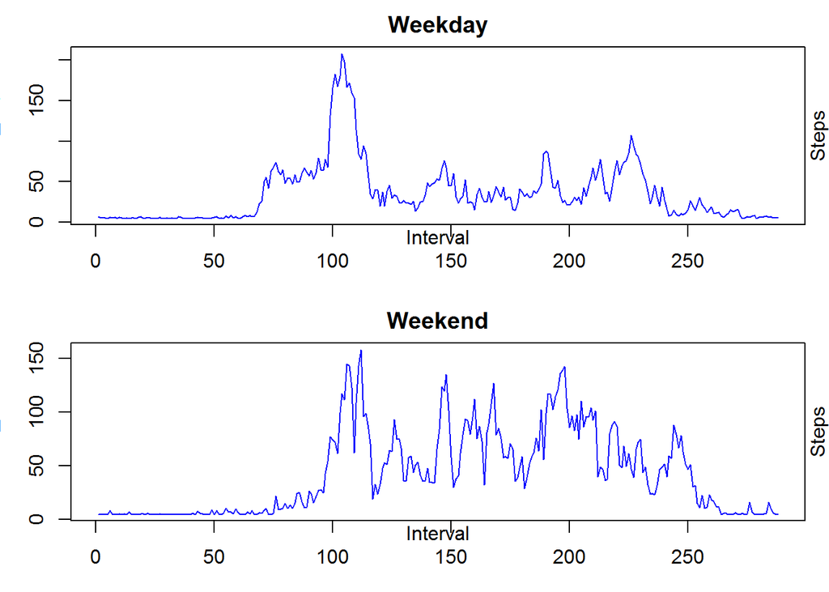

```r
    activity_data_orig$weekday <- weekdays(as.Date(activity_data_orig$date))
    activity_data_orig$weekday[activity_data_orig$weekday=="domingo"] <- "weekend"
    activity_data_orig$weekday[activity_data_orig$weekday=="sábado"] <- "weekend"
    activity_data_orig$weekday[activity_data_orig$weekday!="weekend"] <- "weekday"

    activity_data_orig$newinterval <- rep(seq(1:288),61)
    by_interval2 <- group_by(activity_data_orig, newinterval,weekday)
    total_by_interval2 <- summarise(by_interval2, steps = mean(steps))
    week_day <- total_by_interval2[total_by_interval2$weekday=="weekday",]$steps
    week_end <- total_by_interval2[total_by_interval2$weekday=="weekend",]$steps

    jpeg(file="figure/plot4.jpg")
    par(mfrow=c(2,1))
    par(mar=c(3,3,2,1))
    plot(week_day, type="l", col="blue", main="Weekday",xlab="Interval")
    mtext("Interval", side=1)
    mtext("Steps", side=4)

    plot(week_end, type="l", col="blue", main="Weekend",xlab="interval")
    mtext("Interval", side=1)
    mtext("Steps", side=4)
    dev.off()

    par(mfrow=c(2,1))
    par(mar=c(3,3,2,1))
    plot(week_day, type="l", col="blue", main="Weekday",xlab="Interval")
    mtext("Interval", side=1)
    mtext("Steps", side=4)

    plot(week_end, type="l", col="blue", main="Weekend",xlab="interval")
    mtext("Interval", side=1)
    mtext("Steps", side=4)
```

From these plots we can see the following differences between the patterns of weekdays vs weekends:

- The pattern for the first 65 intervals **is similar**.
- The pattern from interval 66 to interval 95 **is higher for weekdays**.
- The pattern from interval 115 to interval 250 **tends to be higher for weekends**.
- The pattern from interval 251 to interval 288 **is similar**.